# Victim intoxicated cases

Internal only

MaryJo Webster

Last updated: 2018-12-27

# Comparing police actions

Cases where victim was intoxicated versus those where victim was not

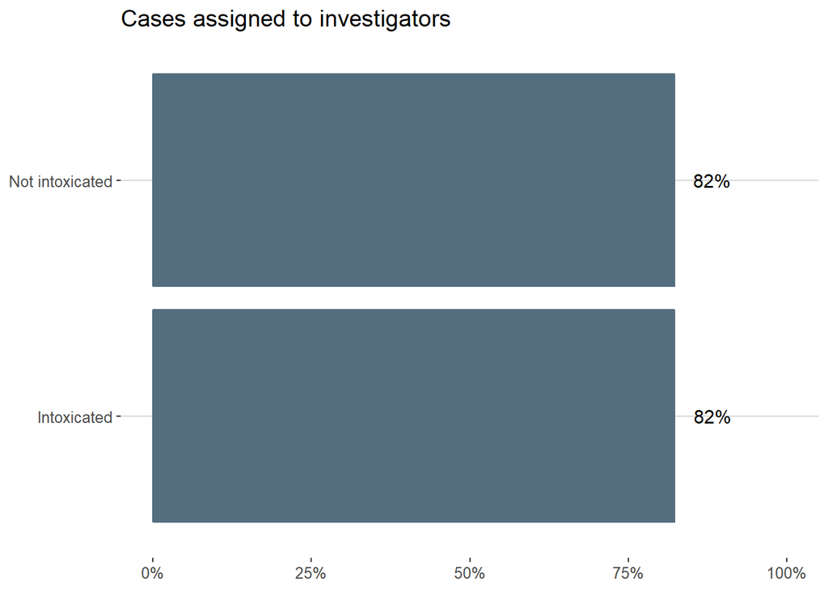

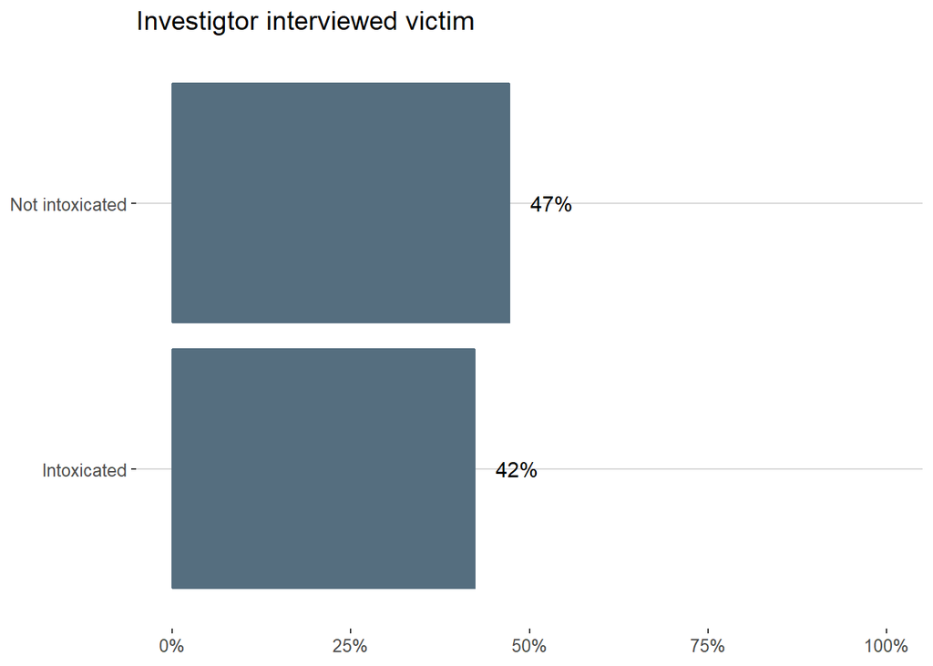

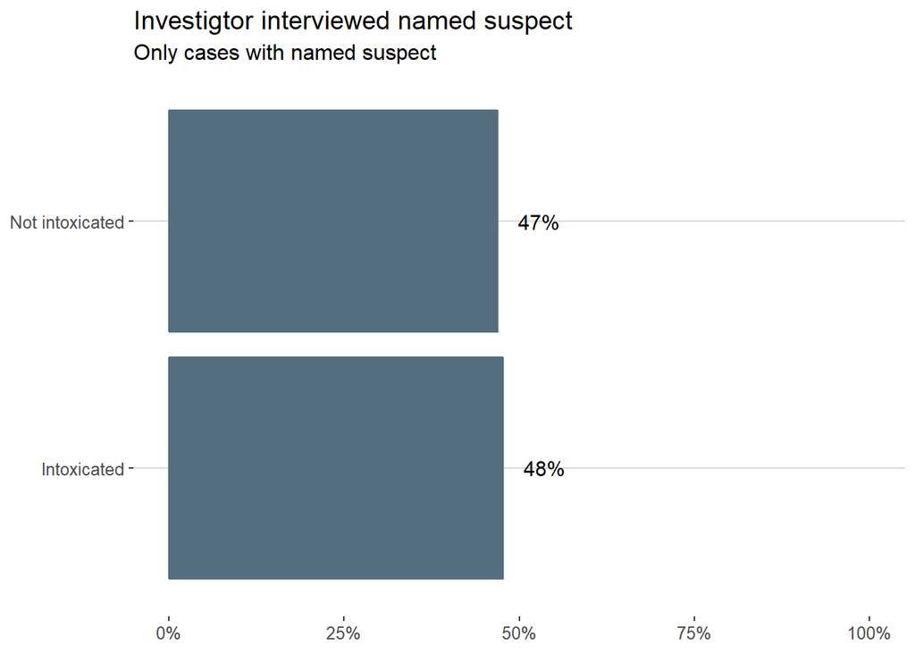

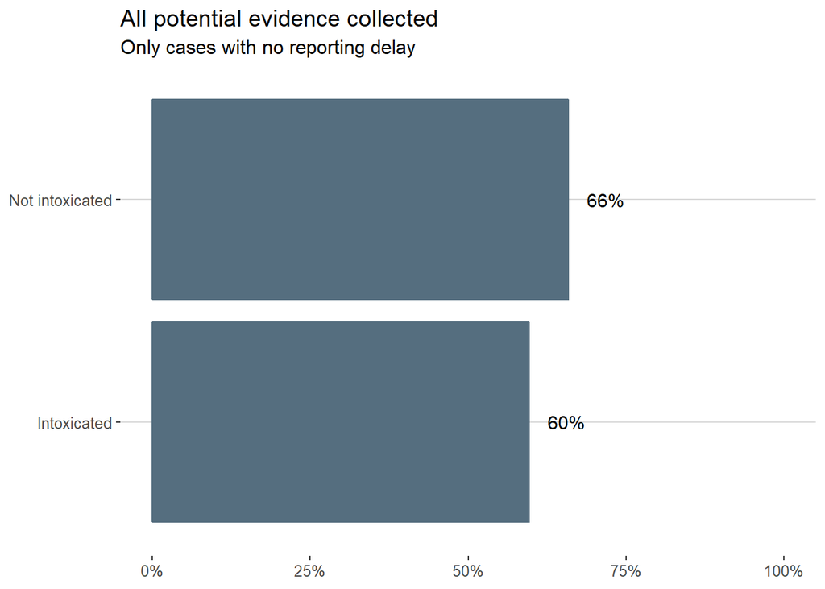

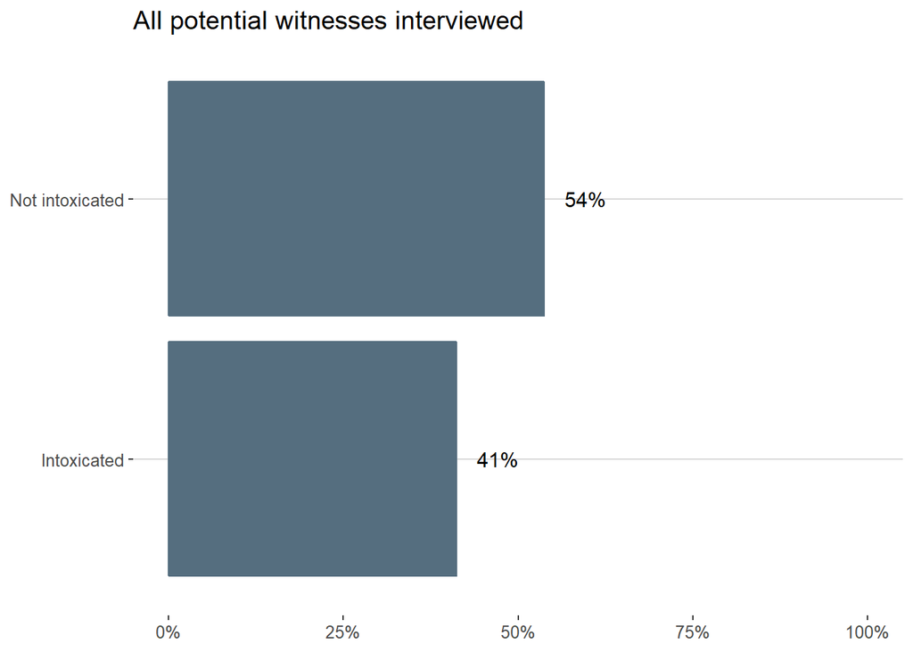

# When victim cooperates

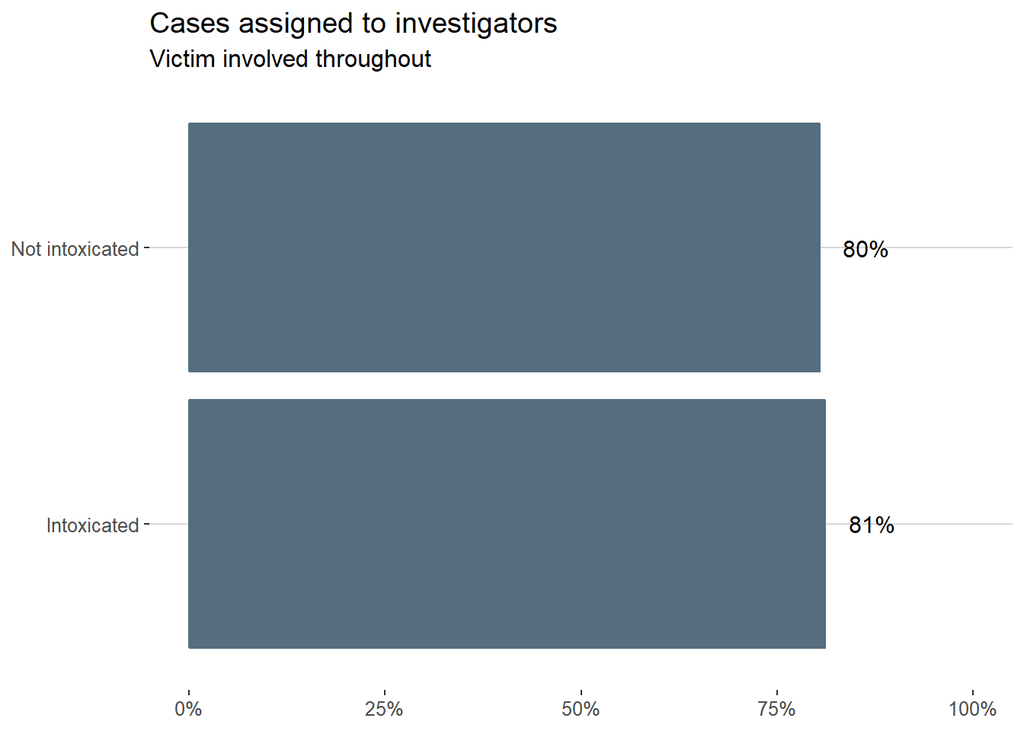

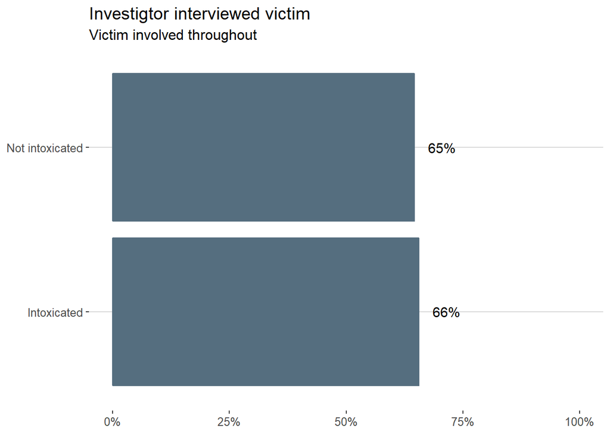

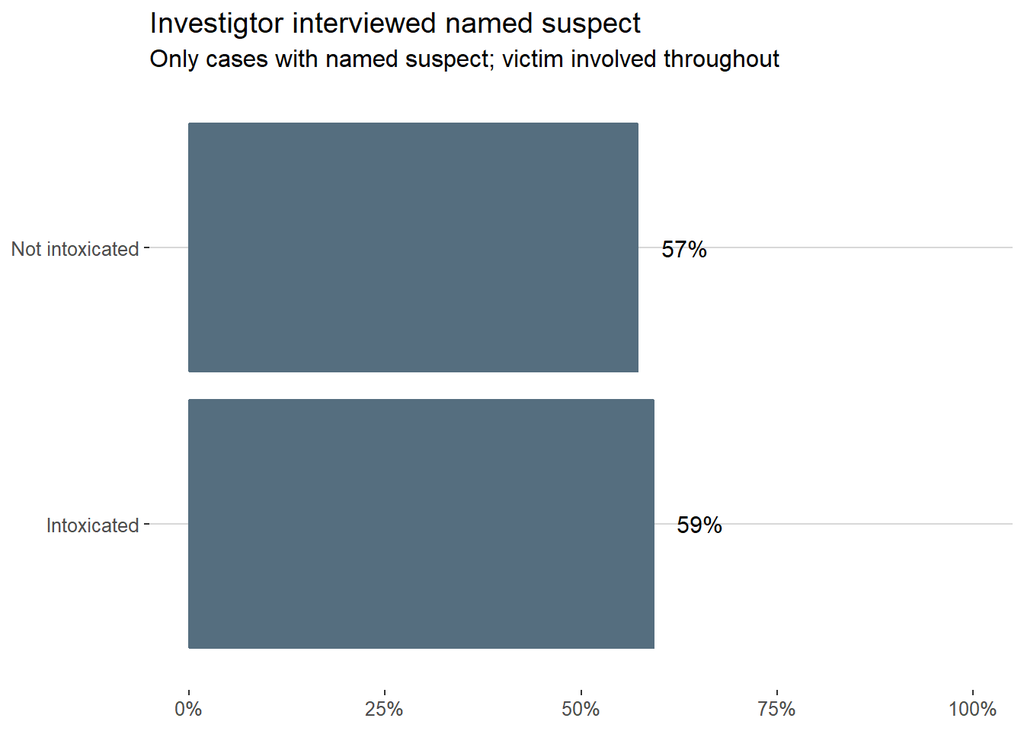

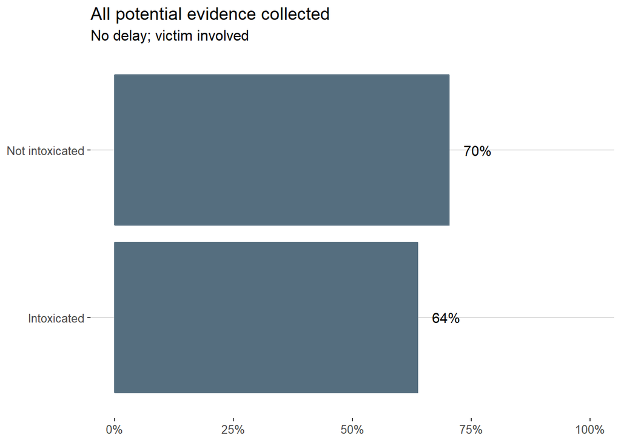

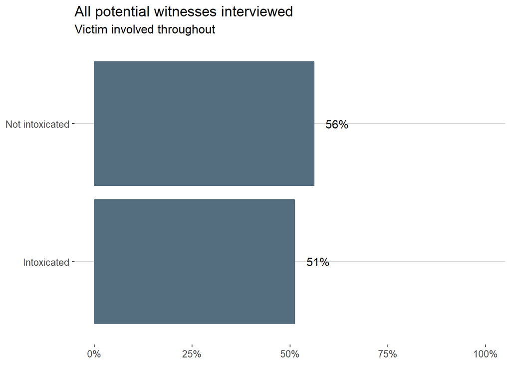

# Comparing outcomes

Cases where victim was intoxicated versus those where victim was not

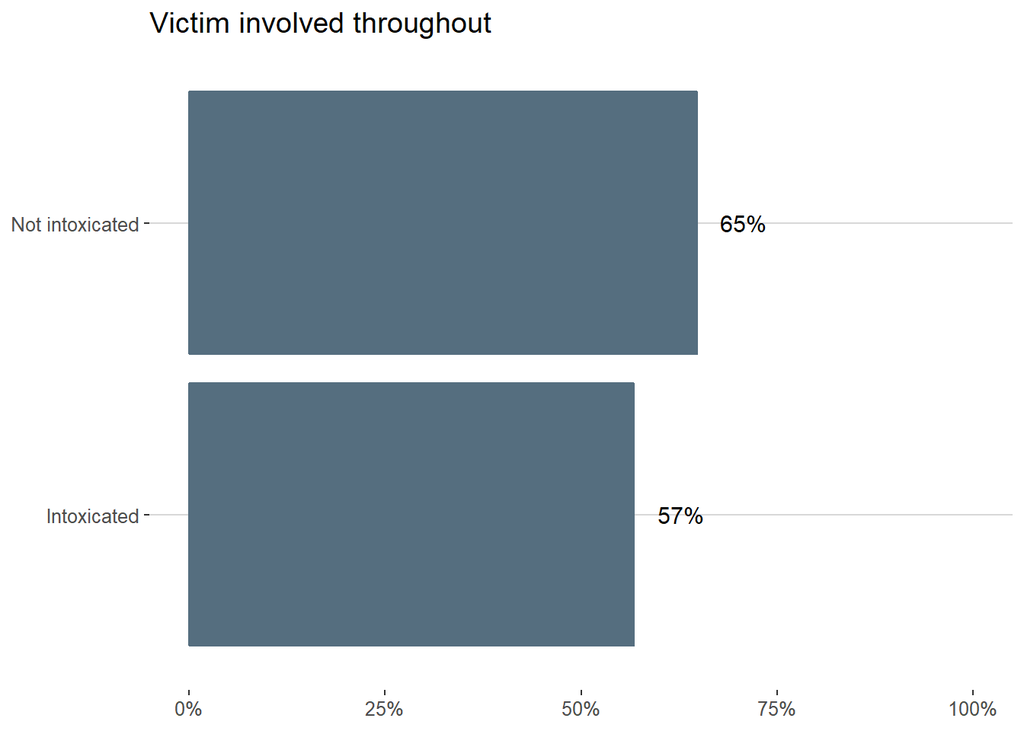

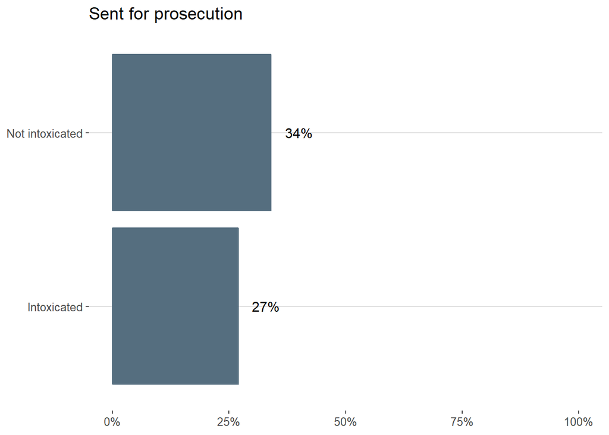

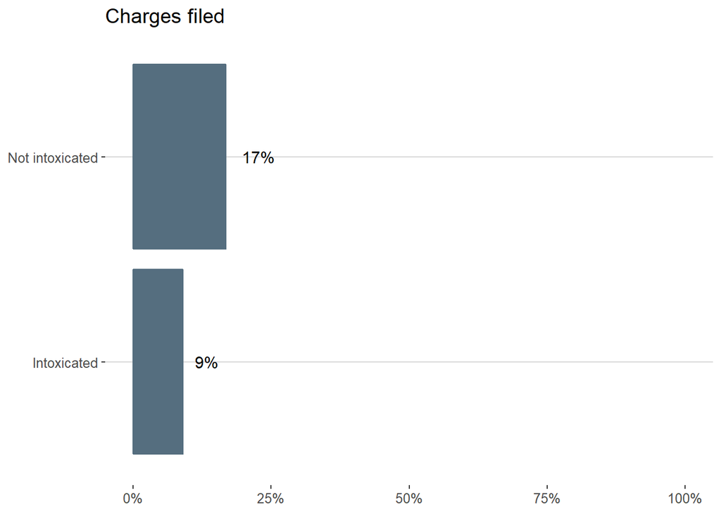

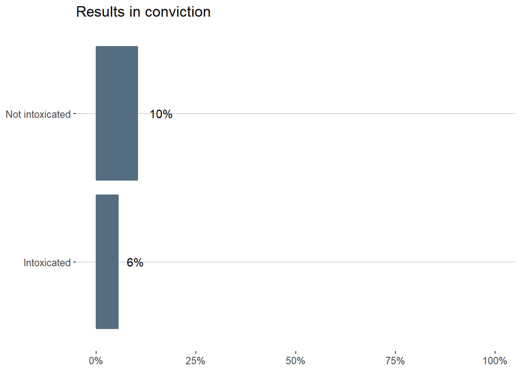

# Older charts

Pct of cases involving intoxicated victim

|  | victimintoxicated |  |  |
| --- | --- | --- | --- |
| legaltype | Yes | No | Unknown |
| Force/Threat/Fear | 11% (97) | 79% (702) | 10% (85) |
| Incapacitation | 73% (160) | 22% (49) | 5% (10) |
| Both | 72% (160) | 17% (38) | 11% (25) |
| Unknown | 9% (13) | 50% (68) | 41% (56) |
| N/A | 0% (0) | 50% (1) | 50% (1) |
| Total | 29% (430) | 59% (858) | 12% (177) |

Victim involvement

Victims who were intoxicated are more likely to withdraw

|  | victiminvolve |  |  |  |
| --- | --- | --- | --- | --- |
| victimintoxicated | Withdrew at some point | Cooperated throughout | Unknown | N/A |
| Yes | 40% | 57% | 3% | 0% |
| No | 29% | 65% | 6% | 0% |
| Unknown | 44% | 44% | 13% | 0% |
| Total | 34% | 60% | 6% | 0% |

Victim involvement by legal type  
Only cases with intoxicated victim

victiminvolve

legaltype

Withdrew at some point

Cooperated throughout

Unknown

N/A

Force/Threat/Fear

40%

55%

5%

0%

Incapacitation

39%

57%

4%

0%

Both

39%

60%

1%

0%

Unknown

62%

31%

8%

0%

N/A

Total

40%

57%

3%

0%

Sent to investigators by victim intoxication

|  | investigatorsassigned |  |  |
| --- | --- | --- | --- |
| victimintoxicated | Yes | No | NA_ |
| Yes | 82% | 17% | 0% |
| No | 82% | 17% | 1% |
| Unknown | 71% | 28% | 1% |
| Total | 81% | 18% | 1% |

Sent for prosecution by victim intoxication

|  | sentforprosecution |  |  |  |
| --- | --- | --- | --- | --- |
| victimintoxicated | Yes | No | Cannot determine | N/A |
| Yes | 45% | 52% | 3% | 0% |
| No | 49% | 48% | 3% | 0% |
| Unknown | 27% | 70% | 3% | 0% |
| Total | 46% | 51% | 3% | 0% |

Charges filed by victim intoxication

|  | chargesfiled |  |  |  |  |
| --- | --- | --- | --- | --- | --- |
| victimintoxicated | Yes | No | Cannot determine | NEED TO CHECK | N/A |
| Yes | 9% | 90% | 1% | 0% | 0% |
| No | 17% | 79% | 4% | 0% | 0% |
| Unknown | 6% | 90% | 3% | 0% | 0% |
| Total | 13% | 83% | 3% | 0% | 0% |

Conviction rates by victim intoxication  
victim intoxicated=yes

|  | conviction |  |  |  |  |
| --- | --- | --- | --- | --- | --- |
| victimintoxicated | Yes | No | Case still pending | Cannot determine | NA_ |
| Yes | 6% | 92% | 1% | 1% | 0% |
| No | 10% | 83% | 0% | 6% | 1% |
| Unknown | 3% | 93% | 0% | 2% | 2% |
| Total | 8% | 87% | 0% | 4% | 1% |

Declined cases  
victim intoxicated=yes  
sent for prosecution = yes

|  | declinedcase |  |
| --- | --- | --- |
| victimintoxicated | Declined | NA |
| Yes | 65% (75) | 35% (41) |
| No | 43% (126) | 57% (166) |
| Unknown | 54% (13) | 46% (11) |
| Total | 50% (214) | 50% (218) |

Potential evidence collected by victim intoxication  
Where no delay in reporting

|  | evidence2 |  |  |
| --- | --- | --- | --- |
| victimintoxicated | All collected | Not all collected | Unknown |
| Yes | 64% | 30% | 6% |
| No | 70% | 17% | 12% |
| Unknown | 55% | 34% | 11% |
| Total | 67% | 22% | 10% |

Potential witnesses interviewed by victim intoxication

|  | witness2 |  |  |
| --- | --- | --- | --- |
| victimintoxicated | All witnesses interviewed | Not all witnesses interviewed | Unknown |
| Yes | 51% | 42% | 7% |
| No | 56% | 35% | 9% |
| Unknown | 45% | 42% | 13% |
| Total | 54% | 37% | 9% |

Victim interviewed by victim intoxication

|  | victiminterviewed |  |  |  |  |
| --- | --- | --- | --- | --- | --- |
| victimintoxicated | Yes | Attempted | No | Other | N/A |
| Yes | 66% | 1% | 30% | 4% | 0% |
| No | 65% | 1% | 32% | 3% | 0% |
| Unknown | 39% | 5% | 48% | 8% | 0% |
| Total | 63% | 1% | 32% | 4% | 0% |

Suspect interviewed by victim intoxication  
Where there is a named suspect

|  | suspectinterviewed |  |  |  |  |  |
| --- | --- | --- | --- | --- | --- | --- |
| victimintoxicated | Yes | Attempted | No | Other | Suspect unknown | N/A |
| Yes | 59% | 14% | 24% | 2% | 1% | 0% |
| No | 57% | 9% | 32% | 1% | 0% | 0% |
| Unknown | 56% | 4% | 36% | 2% | 2% | 0% |
| Total | 58% | 10% | 30% | 2% | 0% | 0% |

Suspect arrested by victim intoxication  
Only cases with a named suspect

|  | suspectarrested |  |  |  |
| --- | --- | --- | --- | --- |
| victimintoxicated | Yes | No | Cannot determine | N/A |
| Yes | 31% | 65% | 5% | 0% |
| No | 39% | 55% | 6% | 0% |
| Unknown | 33% | 65% | 2% | 0% |
| Total | 36% | 58% | 5% | 0% |